# Lab4

## Task 1

$f(x, y) = e^x + y^2, x_0 = 0, y_0 = 1, a = 2, b = 1$

$П = \big\{(x, y) \big| |x| \le 2; |y - 1| \le 1\big\}$

### 1.1

$L = f_{y}^{'} = 2y$

$\max_{(x, y) \in П}{|f_{y}^{'}|} = \max_{(x, y) \in П}{|2y|} = 4$

$f \in C$ $\implies$ satisfies Picard theorem conditions

### 1.2

$M = \max_{(x, y) \in П}{|e^x + y^2|} = e^2 + 4$

$h = \min{a, \frac{b}{M}} = \min{2, \frac{1}{e^2 + }} \implies I_{h} = \big(-\frac{1}{e^2 + 4}; \frac{1}{e^2 + 4}\big)$

### 1.3

$y_{n+1} = y_0 + \int_{0}^{x}{f(\xi, y(\xi))d\xi}$ $y_{n+2} = 1 + \int_{0}^{x}{\big(e^{\xi} + y_{n}^{2}(\xi)\big)d\xi}$

$y_{1} = 1 + \int_{0}^{x}{\big(e^{\xi} + 1\big)d\xi} = 1 + x + e^x$

$y_{2} = 1 + \int_{0}^{x}{\big(e^{\xi} + y_{1}^{2}(\xi)\big)d\xi} = -\frac{3}{2} + \frac{e^{2x}}{2} + x + x^2 + \frac{x^3}{3} + e^x(1 + 2 x)$

$y_{3} = 1 + \int_{0}^{x}{\big(e^{\xi} + y_{2}^{2}(\xi)\big)d\xi} = $

$= \frac{1}{1008}(112e^{3x}(6x + 1) + 63e^{4x} + 42e^{2x}(2x(x(2x + 27) + 3) - 9) + 336e^x(2x(x(x(2x - 1) + 12) - 30) + 51) + 4x(x(x(x(4x(x(x + 7) + 21) + 63) + 168) - 378) + 567) - 16933) + e^x - 1$

### 1.4

$$ \big |y_3(x) - y(x) \big | \le \frac{((e^2 + 4)4^{n-1})}{n!} \big (\frac{1}{e^2 + 4} \big )^{n}$$

## Task 2

### 2.1

$y^{'} = -2\sqrt{y}, x_0 = -1, y_0 = 0, K = \big\{(x, y) \big | x^2 + y^2 \le 16\big\}$

$M = \max_{K}{|-2\sqrt{y}|} = 4$

Choose rectangular sub-area of $K$ to apply Picard theorem, more specifically, let $B = \big\{(x, y)\big||x - 1| \le 1 |y \le 2 \big\}$, hence $h = \min{\{1, \frac{1}{2}\}} = \frac{1}{2}$

$h = \frac{1}{2}, I_{h} = \{-1.5, 0.5\}$

### 2.2

$g_{y}^{'} = -\frac{1}{\sqrt{y}}$

$\max_{K}{|g_{y}^{'}|} = \frac{1}{2} \implies$ yes, satisfies

### 2.3

$$y^{'} = -2\sqrt{y}$$$$\frac{dy}{\sqrt{y}} = -2dx$$$$\frac{dy}{\sqrt{2y}} = -dx$$$$\sqrt{y} = -x + C$$$$y = (C - x)^2; y = 0$$

$y_{min} = 0; y_{max}$ does not exist

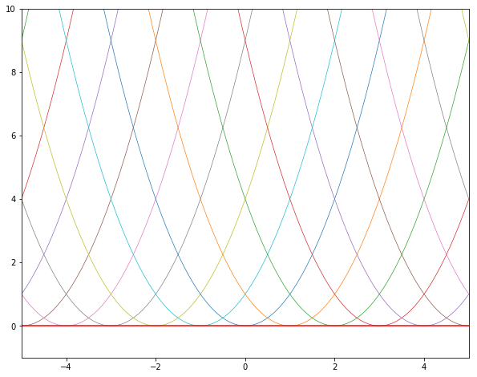

```python
import matplotlib.pyplot as plt
import numpy as np

fig = plt.gcf()
fig.set_size_inches(10, 8)

plt.axis([-5, 5, -1, 10])

x = np.linspace(-5, 5, 100)
for c in range(-20, 21):
    y = (c - x)**2
    plt.plot(x, y, linewidth=0.7)
plt.plot(x, 0*x, 'r')
plt.show()
```

## Task 3

$y^{'} = y + 2e^x, y(0) = 0$

$y_{n + 1} = \int_{0}^{x}{(2e^{\xi} + y_{n}{\xi} d\xi)}$

$y_1 = 2 e^x - 2$

$y_2 = 4 e^x - 2x - 4$

$y_3 = 6 e^x - x^2 - 4x - 6$

$$y_{n} = 2ne^x - \bigg(\frac{2x^{n-1}}{(n-1)!} + \frac{4x^{n-2}}{(n-2)!} + ... + \frac{2(n - 1)x}{1!} + \frac{2n}{0!} \bigg)$$$$ = 2ne^x - \sum_{k = 0}^{n - 1}{\frac{(2n - 2k)}{k!}x^k} = ... = 2t \sum_{i = 0}^{n - 2}{\frac{x^i}{i!}} \rightarrow 2xe^x, n \rightarrow \infty$$

$y^{'} - y = + 2e^x$ - linear equation

$y^{'} - y = 0$ - respective homogenious equation

$y = C(x)e^x; y' = (C'(x) + C(x))e^x$, substituting to original linear will get:

$C'(x)e^x + C(x)e^x = C(x)e^x + 2e^x$

$C'(x) = 2; C(x) = 2x + C_1$

Hence, $y = (2x + C_1)e^x$